[O’Hara on GitHub](https://github.com/oharac)

# Gather stressors and process to analysis CRS

Compiled on Sat Nov 27 20:14:11 2021 by ohara

```r
knitr::opts_chunk$set(echo = TRUE, message = FALSE, warning = FALSE)

library(raster)
library(sf)
library(oharac)
oharac::setup()
source(here('common_fxns.R'))
```

# 1 Summary

Gather stressor layers and process to the CRS for this analysis: Mollweide, 10 km x 10 km. Identify gapfill needs if necessary.

# 2 Data

All files are located on Mazu, starting from `/home/shares/ohi/` unless otherwise noted.

## 2.1 Fishing-related stressors other than targeted biomass removal

- GFW data to estimate benthic disturbance from food systems project:
  - dir: `stressors_2021/_dataprep/fishing_benthic_destructive`
    - file: `FishingWatch_annual_effort_destructive_hours_2017.tif`
  - cite food systems project where GFW data was processed to this layer?
  - or cite GFW and include methods/code to generate this layer within this project.
  - Information from the food systems project: https://github.com/OHI-Science/food_systems/tree/master/fisheries/marine/disturbance
- Artisanal and Commercial High Bycatch fishing from OHI 2021
  - dir: `git-annex/globalprep/prs_fish/v2020/output/`
    - in this, subdirs: `art_high_bycatch`, `art_low_bycatch`, `comm_high_bycatch`, `comm_low_bycatch`
    - in subdirs: `art_high_bycatch/ahb_fish_pressure_2013_2017.tif` and `comm_high_bycatch/hb_fish_pressure_2013_2017.tif`
  - From Watson data, 0.5° rasters.

## 2.3 Climate stressors other than SST

- Sea level rise from OHI 2021
  - Use annual mean SLR anomaly rasters from here:
    - dir: `git-annex/globalprep/prs_slr/v2021/int/msla_annual_mean/`
      - file: `msla_annual_2019.tif`
    - These are pre-transform and mask. Transformed and masked are also available, but let’s use these so we can make sure the transform and mask are accurate to our particular CRS.
  - See OHI processing script for details: `https://github.com/OHI-Science/ohiprep_v2021/blob/gh-pages/globalprep/prs_slr/v2021/slr_layer_prep_v2.Rmd`
- Ocean acidification from CHI Pace of Change (2017 data year)
  - dir: `git-annex/impact_acceleration/stressors/oa/final`
    - file: `oa_2017_rescaled_mol.tif`
  - These are in Mollweide but at 934 meter resolution… reproject to 10 km
  - Or, use OHI or CHI processing script to process from raw data?
- Ultraviolet radiation from OHI 2021
  - dir: `git-annex/globalprep/prs_uv/v2021/int/rescaled/`
    - file: `annual_diff_2016_2020_rescaled.tif`
  - See OHI processing script for details: `https://ohi-science.org/ohiprep_v2020/globalprep/prs_uv/v2020/uv_dataprep.html`

## 2.4 Ocean-based stressors

- Benthic structures?
- Shipping?

## 2.5 Sensory pollution

- Light pollution?
- Noise pollution?

# 3 Methods

For each stressor layer, reproject to 10 km Mollweide CRS and mask to ocean cells.

From `?projectRaster`:

> Note: If the resolution of the output is much larger than that of the input, you should first aggregate the input such that the resolution of the input becomes more similar (perhaps a little smaller) to the output.

```r
here_ohi <- function(f = '') {
  sprintf('/home/shares/ohi/%s', f)
}

ocean_rast <- raster(here('_spatial/ocean_area_mol.tif'))
```

## 3.1 Fishing-related stressors other than targeted biomass removal

### 3.1.1 Global Fishing Watch for benthic disturbance

Reproject, then rescale 0-1.

These data are extremely right-skewed - instead of $\log(x+1)$ transform try inverse hyperbolic sine from https://marcfbellemare.com/wordpress/12856:
$$IHS(x) = \log(x + \sqrt{x^2 + 1})$$
The `ihs()` and `log_plus()` functions I define here allow for adding a given constant (e.g., 1), but default to a value of $\max(x)/1000$, to reduce (for `ihs()`) or eliminate (for `log_plus()`) scale dependence.

For these layers, let’s use the `log_plus()` transformation as more simple.

```r
ihs <- function(x, add = NULL) {
  ### inverse hyperbolic sine from https://marcfbellemare.com/wordpress/12856
  ### modified so the added component is relative to x, for consistency
  ### across scales.  Can set add to be a numeric value to override.
  if(is.null(add)) {
    add <- max(x, na.rm = TRUE)/1000
  }
  y <- log(x + sqrt(x^2 + add))
  ### still seems scale dependent though!
}

log_plus <- function(x, add = NULL) {
  ### inverse hyperbolic sine from https://marcfbellemare.com/wordpress/12856
  ### modified so the added component is relative to x, for consistency
  ### across scales.  Can set add to be a numeric value to override.
  if(is.null(add)) {
    add <- max(x, na.rm = TRUE)/1000
  }
  y <- log(x + add)
  ### still seems scale dependent though!
}

rescale <- function(x, qtile = NULL) {

  xmin <- min(x, na.rm = TRUE)
  if(is.null(qtile)) {
    xmax = max(x, na.rm = TRUE)
  } else {
    xmax = quantile(x, qtile, na.rm = TRUE)
  }
  y <- (x - xmin) / (xmax - xmin)
  ### in case of quantile, clip results to 1
  z <- ifelse(y > 1, 1, y)
  return(z)
}

### testing out functions
# df <- data.frame(x = 1:1000) %>%
#   mutate(y = 10 * x,
#          ihs_x = ihs(x),
#          ihs_y = ihs(y),
#          log2_x = log_plus(x),
#          log2_y = log_plus(y),
#          ihs2_x = ihs(x, add = 10),
#          ihs2_y = ihs(y, add = 10),
#          log_x = log(x+1),
#          log_y = log(y+1)) %>%
#   gather(var, val, -x, -y) %>%
#   group_by(var) %>%
#   mutate(val = rescale(val))
#
# ggplot(df %>% filter(str_detect(var, 'ihs_')), aes(x = x, y = val)) +
#   geom_line(aes(color = var)) +
#   scale_color_viridis_d()
# ggplot(df %>% filter(str_detect(var, 'log2_')), aes(x = x, y = val)) +
#   geom_line(aes(color = var)) +
#   scale_color_viridis_d()
# ggplot(df %>% filter(str_detect(var, 'ihs2_')), aes(x = x, y = val)) +
#   geom_line(aes(color = var)) +
#   scale_color_viridis_d()
### log_plus() when rescaled returns the exact same number (log of higher
### scale is just an additive constant relative to lower).
### ihs() with scale-determined additive value is very very similar
### across scales, but not exact.
```

GFW data for OHI at 0.01 degree resolution. Aggregate by a factor of about 10x to get closer to 10 km x 10 km target resolution (at equator…). Perform transformation prior to aggregation, so mean aggregates the log-transformed data. This will squash the effects of huge outliers a bit, and boost the influence of lower-value cells in the mean.

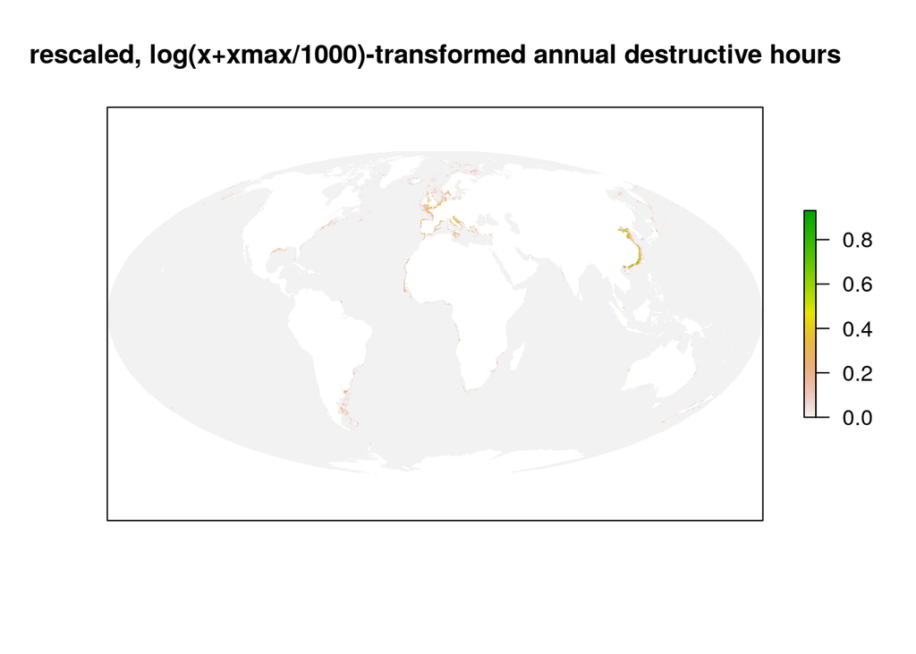

```r
benth_dist_f <- here('_data/stressors_mol/fishing_benthic_dest_2017.tif')
### unlink(benth_dist_f)

if(!file.exists(benth_dist_f)) {
  orig_f <- here_ohi(paste('stressors_2021/_dataprep', 'fishing_benthic_destructive',
                           'FishingWatch_annual_effort_destructive_hours_2017.tif', sep = '/'))
  orig_r <- raster(orig_f)
  # class      : RasterLayer
  # dimensions : 18000, 36000, 6.48e+08  (nrow, ncol, ncell)
  # resolution : 0.01, 0.01  (x, y)
  # extent     : -180.005, 179.995, -89.995, 90.005  (xmin, xmax, ymin, ymax)
  # crs        : +proj=longlat +datum=WGS84 +no_defs
  # source     : FishingWatch_annual_effort_destructive_hours_2017.tif
  # names      : FishingWatch_annual_effort_destructive_hours_2017
  # values     : 0, 1540.895  (min, max)

  ### mask to just ocean cells to avoid land-based zeros from influencing mean
  ocean_mask_sf <- read_sf(here('_spatial/ne_10m_ocean/ne_10m_ocean.shp'))
  ocean_mask_r <- fasterize::fasterize(ocean_mask_sf, orig_r)
  masked_r <- mask(orig_r, ocean_mask_r, progress = 'text')

  ### perform log_plus transform, aggregate by mean, reproject.
  log_r <- masked_r
  values(log_r) <- log_plus(values(log_r))
  agg_log_r <- aggregate(log_r, fact = 10, fun = 'mean', progress = 'text')
  reproj_log_r <- projectRaster(agg_log_r, ocean_rast, progress = 'text')

  ### rescale the reprojected raster, fill all NAs with 0, then mask to just ocean
  values(reproj_log_r) <- rescale(values(reproj_log_r))
  values(reproj_log_r)[is.na(values(reproj_log_r))] <- 0

  log_r_ocean <- mask(reproj_log_r, ocean_rast, progress = 'text')

  ### round to drop ludicrous precision then save out
  values(log_r_ocean) <- round(values(log_r_ocean), 5)
  writeRaster(log_r_ocean, benth_dist_f, overwrite = TRUE)

}

r <- raster(benth_dist_f)

plot(r, axes = FALSE,
     main = 'rescaled, log(x+xmax/1000)-transformed annual destructive hours')
```

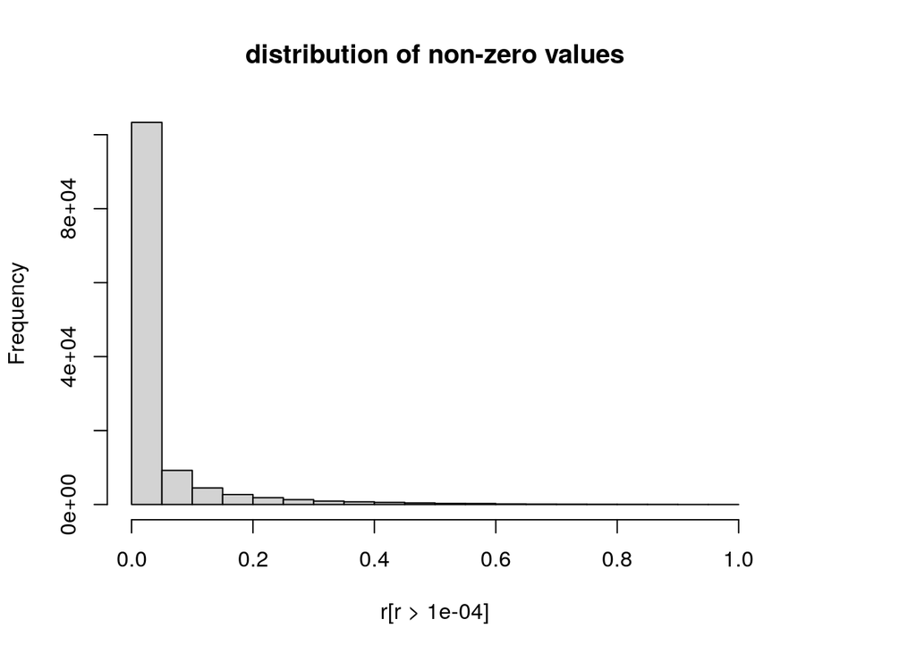

```r
hist(r[r > 0.0001], main = 'distribution of non-zero values')
```

### 3.1.2 Artisanal and Commercial High Bycatch fishing

```
* dir: `git-annex/globalprep/prs_fish/v2020/output/`
    * in this, subdirs: `art_high_bycatch`, `art_low_bycatch`, `comm_high_bycatch`, `comm_low_bycatch`
    * in subdirs: `art_high_bycatch/ahb_fish_pressure_2013_2017.tif` and `comm_high_bycatch/hb_fish_pressure_2013_2017.tif`
* From Watson data, 0.5° rasters.
```

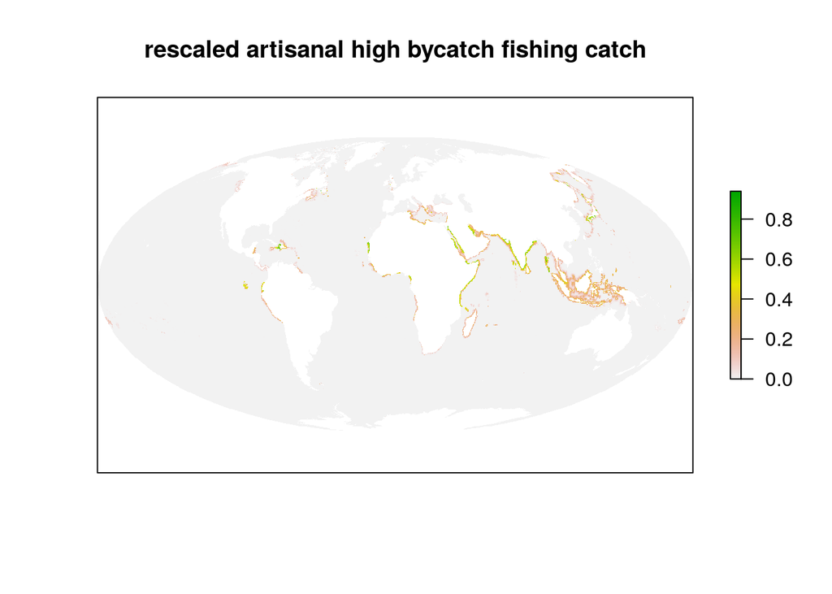

```r
abh_f <- here('_data/stressors_mol/art_high_bycatch_2017.tif')
### unlink(abh_f)

if(!file.exists(abh_f)) {
  orig_f <- here_ohi(paste('git-annex/globalprep/prs_fish/v2020/output',
                           'art_high_bycatch',
                           'ahb_fish_pressure_2013_2017.tif', sep = '/'))
  orig_r <- raster(orig_f)
  # class      : RasterLayer
  # dimensions : 19305, 38610, 745366050  (nrow, ncol, ncell)
  # resolution : 934.4789, 934.4789  (x, y)
  # extent     : -18040095, 18040134, -9020047, 9020067  (xmin, xmax, ymin, ymax)
  # crs        : +proj=moll +lon_0=0 +x_0=0 +y_0=0 +ellps=WGS84 +units=m +no_defs
  # source     : ahb_fish_pressure_2013_2017.tif
  # names      : ahb_fish_pressure_2013_2017
  # values     : 0, 1  (min, max)

  ### Already in Mollweide and rescaled, but wrong resolution... aggregate up to ~ 10 km
  agg_r <- aggregate(orig_r, fact = 10, fun = 'mean', progress = 'text')
  ahb_r <- projectRaster(agg_r, ocean_rast, progress = 'text')

  ### rescale the reprojected raster, fill all NAs with 0, then mask to just ocean
  values(ahb_r) <- rescale(values(ahb_r))
  values(ahb_r)[is.na(values(ahb_r))] <- 0
  ahb_r_ocean <- mask(ahb_r, ocean_rast, progress = 'text')

  ### round to drop ludicrous precision then save out
  values(ahb_r_ocean) <- round(values(ahb_r_ocean), 5)
  writeRaster(ahb_r_ocean, abh_f)

}

r <- raster(abh_f)

plot(r, axes = FALSE,
     main = 'rescaled artisanal high bycatch fishing catch')
```

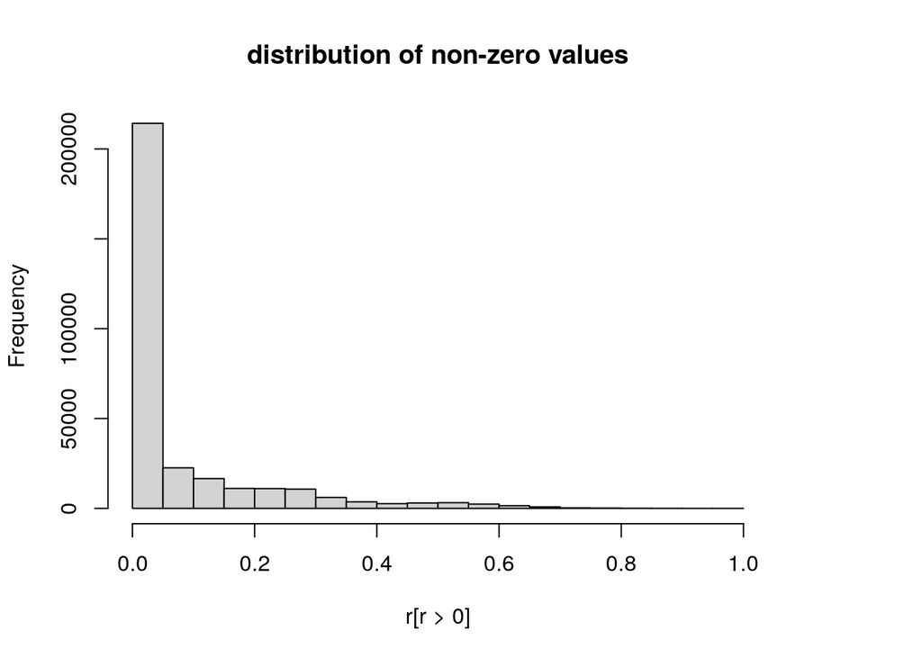

```r
hist(r[r > 0], main = 'distribution of non-zero values')
```

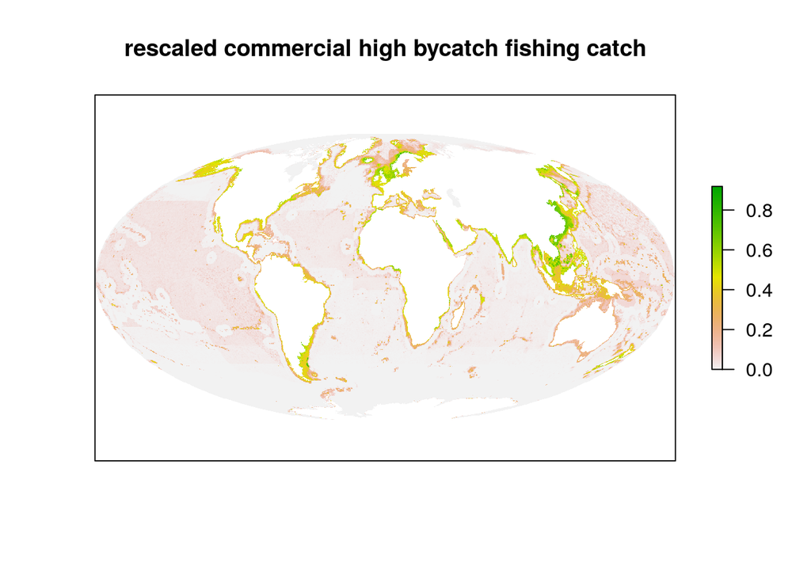

```r
chb_f <- here('_data/stressors_mol/comm_high_bycatch_2017.tif')
### unlink(chb_f)

if(!file.exists(chb_f)) {
  orig_f <- here_ohi(paste('git-annex/globalprep/prs_fish/v2020/output',
                           'comm_high_bycatch',
                           'hb_fish_pressure_2013_2017.tif', sep = '/'))
  orig_r <- raster(orig_f)
  # class      : RasterLayer
  # dimensions : 19305, 38610, 745366050  (nrow, ncol, ncell)
  # resolution : 934.4789, 934.4789  (x, y)
  # extent     : -18040095, 18040134, -9020047, 9020067  (xmin, xmax, ymin, ymax)
  # crs        : +proj=moll +lon_0=0 +x_0=0 +y_0=0 +ellps=WGS84 +units=m +no_defs
  # source     : ahb_fish_pressure_2013_2017.tif
  # names      : ahb_fish_pressure_2013_2017
  # values     : 0, 1  (min, max)

  ### Already in Mollweide and rescaled, but wrong resolution... aggregate up to near 10 km
  agg_r <- aggregate(orig_r, fact = 10, fun = 'mean', progress = 'text')
  chb_r <- projectRaster(agg_r, ocean_rast, progress = 'text')

  ### rescale the reprojected raster, fill all NAs with 0, then mask to just ocean
  values(chb_r) <- rescale(values(chb_r))
  values(chb_r)[is.na(values(chb_r))] <- 0

  chb_r_ocean <- mask(chb_r, ocean_rast, progress = 'text')

  ### round to drop ludicrous precision then save out
  values(chb_r_ocean) <- round(values(chb_r_ocean), 5)
  writeRaster(chb_r_ocean, chb_f)

}

r <- raster(chb_f)

plot(r, axes = FALSE,
     main = 'rescaled commercial high bycatch fishing catch')
```

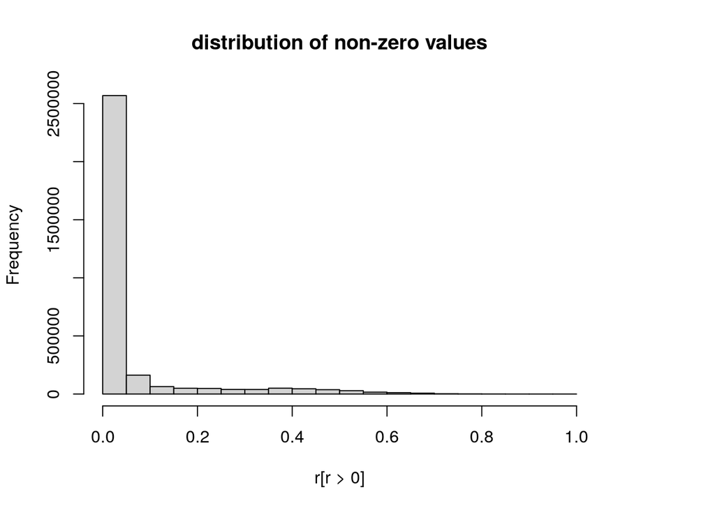

```r
hist(r[r > 0], main = 'distribution of non-zero values')
```

## 3.2 Land-based stressors

### 3.2.1 Nutrient pollution from OHI 2021 plume model

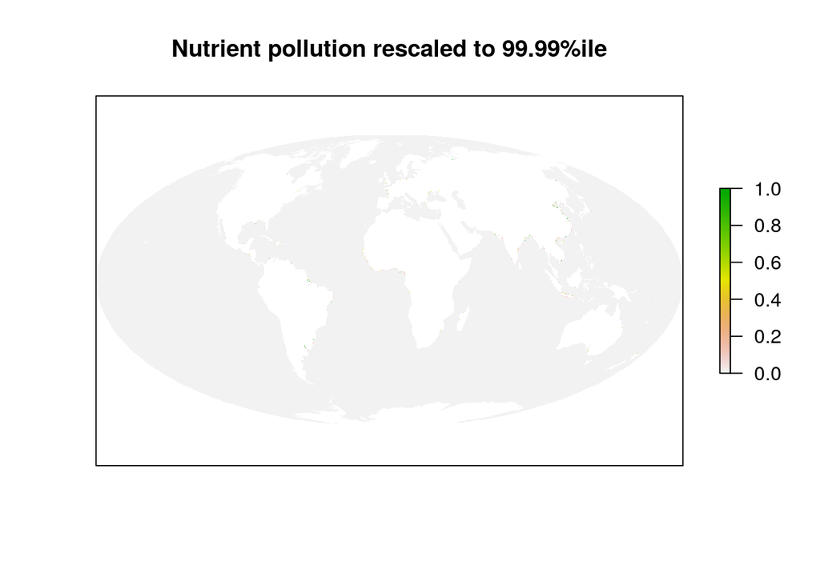

```r
new_f <- here('_data/stressors_mol/nutrient_plume_2019.tif')
### unlink(new_f)

if(!file.exists(new_f)) {
  orig_f <- here_ohi(paste('git-annex/globalprep/prs_land-based_nutrient',
                           'v2021/output/N_plume',
                           'pourpoints_crop_manure_leached_volt_N_2019_joined.tif', sep = '/'))
  orig_r <- raster(orig_f)
  # class      : RasterLayer
  # dimensions : 16981, 43465, 738079165  (nrow, ncol, ncell)
  # resolution : 0.008333333, 0.008333333  (x, y)
  # extent     : -181.0083, 181.2, -57.33333, 84.175  (xmin, xmax, ymin, ymax)
  # crs        : +proj=longlat +datum=WGS84 +no_defs
  # source     : pourpoints_crop_manure_leached_volt_N_2019_joined.tif
  # names      : pourpoints_crop_manure_leached_volt_N_2019_joined

  ### mask to just ocean cells to avoid land-based zeros from influencing mean
  ocean_mask_sf <- read_sf(here('_spatial/ne_10m_ocean/ne_10m_ocean.shp'))
  ocean_mask_r <- fasterize::fasterize(ocean_mask_sf, orig_r)
  masked_r <- mask(orig_r, ocean_mask_r, progress = 'text')

  ### Aggregate up to ~ 10 km, 0.1°, then reproject
  agg_r <- aggregate(masked_r, fact = 12, fun = 'mean', progress = 'text')
  nutr_r <- projectRaster(agg_r, ocean_rast, progress = 'text')

  values(nutr_r) <- rescale(values(nutr_r), qtile = .9999)
  values(nutr_r)[is.na(values(nutr_r))] <- 0
  nutr_r_ocean <- mask(nutr_r, ocean_rast, progress = 'text')

  ### round to drop ludicrous precision then save out
  values(nutr_r_ocean) <- round(values(nutr_r_ocean), 5)
  writeRaster(nutr_r_ocean, new_f)

}

r <- raster(new_f)

plot(r, axes = FALSE,
     main = 'Nutrient pollution rescaled to 99.99%ile')
```

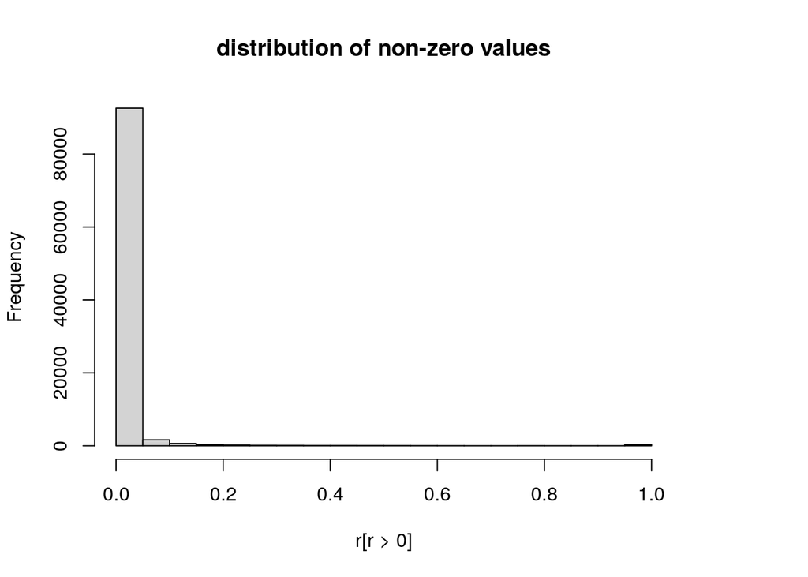

```r
hist(r[r > 0], main = 'distribution of non-zero values')
```

### 3.2.2 Direct human impact/habitat destruction using population as proxy

The data for this is population density or count (on land). We want an indication of the number of people living within 25 km (or so) of the coast. To do this, try `raster::focal()`: Calculate focal (“moving window”) values for the neighborhood of focal cells using a matrix of weights, perhaps in combination with a function.

- To get a circular window on the 934 m native resolution of OHI population data, use a matrix with 55 rows and columns. Assign value of 1 for cells within a 27-cell radius of the center.
- Fill all NAs with zeros, then apply `focal()` to sum up the total population within the circular window, and fill the cell with that value.
- Then mask to just coastal cells, which have now been filled with population within 25 km. As the cells edge out from shore, the farther cells will have lower values, and aggregating/reprojecting to 10 km will be affected by this as it will bring down the average; but since we are rescaling the results from 0 to 1, this should not be a critical concern.

Rescale based on 99.99%ile, without transformation. Seems like a linear relationship between number of people and their impact makes sense.

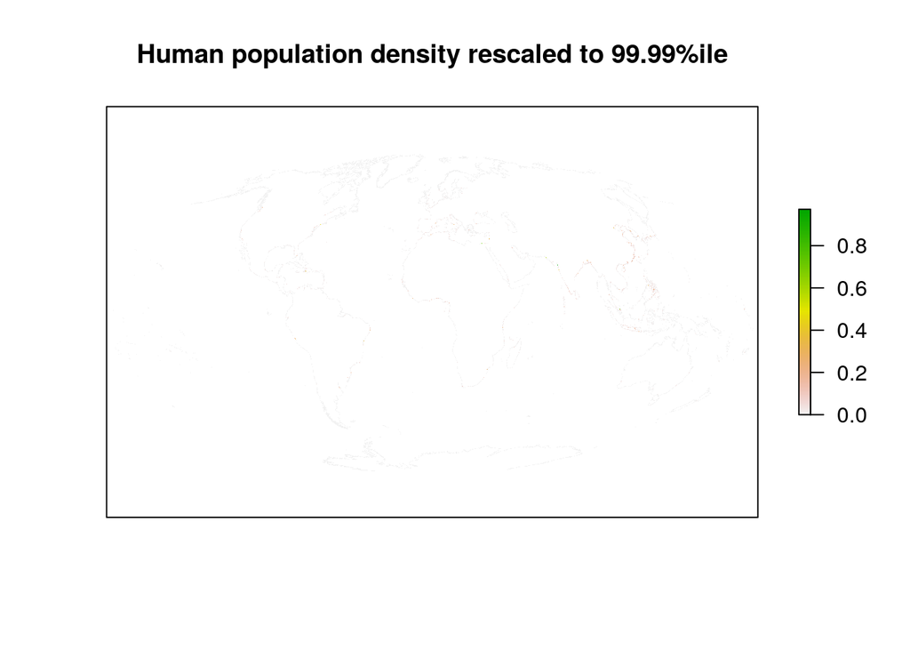

```r
pop_f <- here('_data/stressors_mol/direct_human_2020.tif')
### unlink(pop_f)

if(!file.exists(pop_f)) {
  orig_f <- here_ohi(paste('git-annex/globalprep/mar_prs_population/v2020/int/',
                           'human_density_2020_mol.tif', sep = '/'))
  orig_r <- raster(orig_f)
  # class      : RasterLayer
  # dimensions : 19305, 38610, 745366050  (nrow, ncol, ncell)
  # resolution : 934.4789, 934.4789  (x, y)
  # extent     : -18040095, 18040134, -9020047, 9020067  (xmin, xmax, ymin, ymax)
  # crs        : +proj=moll +lon_0=0 +x_0=0 +y_0=0 +datum=WGS84 +units=m +no_defs
  # source     : human_density_2020_mol.tif
  # names      : human_density_2020_mol
  # values     : 0, 101691.8  (min, max)

  pop_r <- orig_r
  values(pop_r)[is.na(values(pop_r))] <- 0

  ### set up focal matrix - weight of 1 within 25 km, 0 outside
  focal_rad <- 27
  focal_dia <- focal_rad*2+1
  focal_mtx <- matrix(nrow = focal_dia, ncol = focal_dia)
  for(i in 1:focal_dia) {
    for(j in 1:focal_dia) {
      ### i <- 1; j <- 1
      r_from_center <- sqrt((i - (focal_rad + 1))^2 + (j - (focal_rad + 1))^2)
      focal_mtx[i, j] <- ifelse(r_from_center < focal_rad, 1, 0)
    }
  }
  ### Calculate focal sum of population (or pop density, for equal area
  ### there is no meaningful difference when rescaling anyway)
  focal_pop_r <- focal(pop_r, w = focal_mtx, fun = sum, na.rm = TRUE, progress = 'text')

  ### Already in Mollweide, but wrong resolution... aggregate up to ~ 10 km
  agg_focal_pop_r <- aggregate(focal_pop_r, fact = 10, fun = 'mean', progress = 'text')
  agg_focal_pop_r_10km <- projectRaster(agg_focal_pop_r, ocean_rast, progress = 'text')

  ### Masking to coastal cells rather than whole ocean, then
  ### rescale based on cropped raster to 99.99%ile
  coastal_r <- raster(here('_spatial/coastal_3nmi_area_mol.tif'))
  pop_coastal <- mask(agg_focal_pop_r_10km, coastal_r, progress = 'text')

  values(pop_coastal) <- rescale(values(pop_coastal), qtile = .9999)

  ### round to drop ludicrous precision then save out
  values(pop_coastal) <- round(values(pop_coastal), 5)
  writeRaster(pop_coastal, pop_f)

}

r <- raster(pop_f)

plot(r, axes = FALSE,
     main = 'Human population density rescaled to 99.99%ile')
```

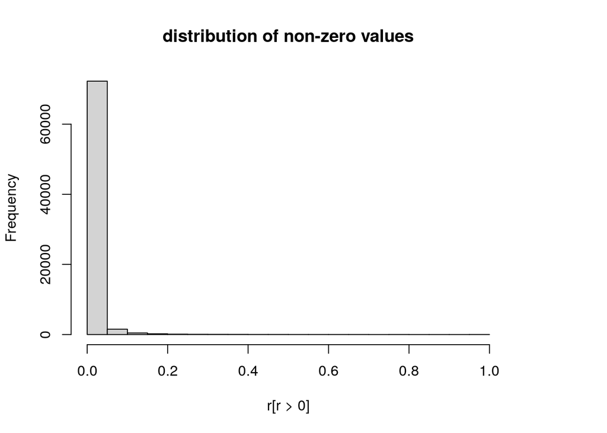

```r
hist(r[r > 0], main = 'distribution of non-zero values')
```

## 3.3 Climate stressors other than SST

### 3.3.1 Sea level rise from OHI 2021

```
* Use annual mean SLR anomaly rasters from here:
    * dir: `git-annex/globalprep/prs_slr/v2021/int/msla_annual_mean/`
        * file: `msla_annual_2019.tif`
    * These are pre-transform and mask.  Transformed and masked are also available, but let's use these so we can make sure the transform and mask are accurate to our particular CRS.
* See OHI processing script for details: `https://github.com/OHI-Science/ohiprep_v2021/blob/gh-pages/globalprep/prs_slr/v2021/slr_layer_prep_v2.Rmd`
```

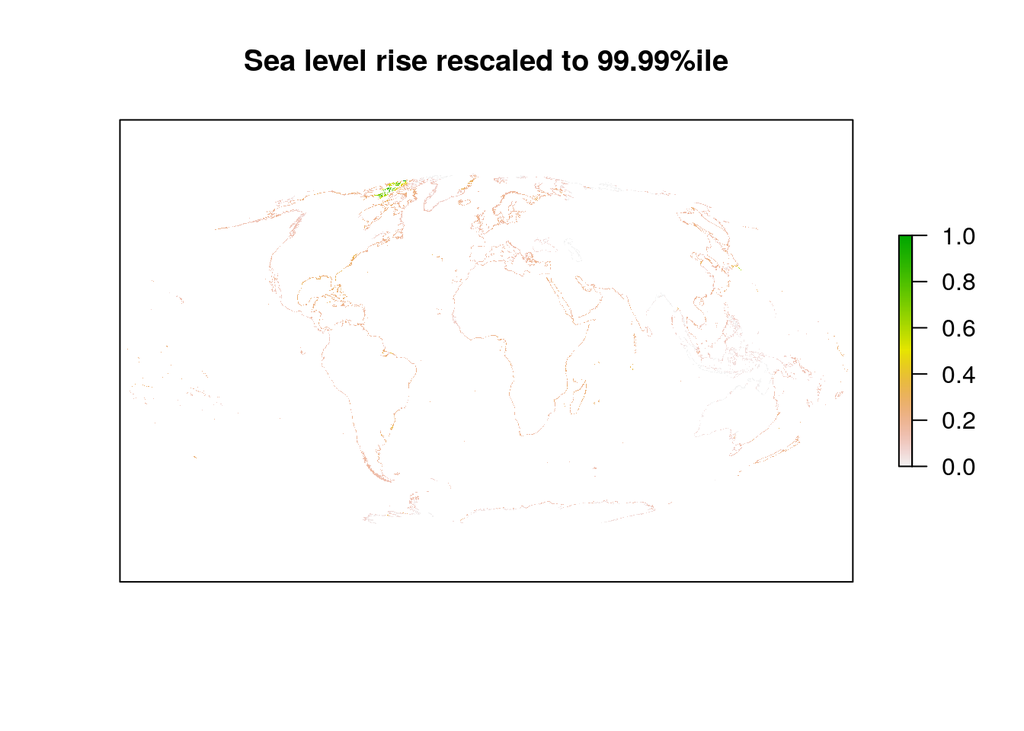

```r
slr_f <- here('_data/stressors_mol/slr_2019.tif')
### unlink(slr_f)

if(!file.exists(slr_f)) {
  orig_f <- here_ohi(paste('git-annex/globalprep/prs_slr/v2021/int/msla_annual_mean/',
                           'msla_annual_2019.tif', sep = '/'))
  orig_r <- raster(orig_f)
  # class      : RasterLayer
  # dimensions : 720, 1440, 1036800  (nrow, ncol, ncell)
  # resolution : 0.25, 0.25  (x, y)
  # extent     : -180, 180, -90, 90  (xmin, xmax, ymin, ymax)
  # crs        : +proj=longlat +datum=WGS84 +no_defs
  # source     : msla_annual_2019.tif
  # names      : msla_annual_2019
  # values     : -1.201033, 0.6790083  (min, max)

  ### In WGS84, .25 degree, so large enough res for projectRaster directly.
  ### First, use focal interpolation of mean of neighboring cells within
  ### a degree (inverse distance weighting) to help make raw SLR layer
  ### extends all the way to coastline.
  focal_rad <- 4
  focal_dia <- focal_rad*2+1
  focal_mtx <- matrix(nrow = focal_dia, ncol = focal_dia)
  for(i in 1:focal_dia) {
    for(j in 1:focal_dia) {
      ### i <- 1; j <- 1
      d <- sqrt((i - (focal_rad + 1))^2 + (j - (focal_rad + 1))^2)
      focal_mtx[i, j] <- 1 / d
    }
    focal_mtx[focal_rad + 1, focal_rad + 1] <- 1
  }
  gf_r <- focal(orig_r, focal_mtx,
                fun = mean, na.rm = TRUE, progress = 'text')

  ### replace NA cells in the original with their counterparts in gf_r_only
  combo <- orig_r
  values(combo)[is.na(values(combo))] <- values(gf_r)[is.na(values(combo))]

  ### Project to Mollweide 10km and masking to coastal cells
  slr_moll_r <- projectRaster(combo, ocean_rast, progress = 'text')
  coastal_r  <- raster(here('_spatial/coastal_3nmi_area_mol.tif'))

  slr_coastal_r <- mask(slr_moll_r, coastal_r, progress = 'text')
  # missing <- coastal_r
  # values(missing)[!is.na(values(slr_coastal_r))] <- NA
  # plot(missing, col = 'red')
  # ### still 4161 coastal cells missing values - polar regions

  ### Set negative values to zero, then rescale
  values(slr_coastal_r)[values(slr_coastal_r) < 0] <- 0
  values(slr_coastal_r) <- rescale(values(slr_coastal_r), qtile = .9999)

  ### round to drop ludicrous precision then save out
  values(slr_coastal_r) <- round(values(slr_coastal_r), 5)
  writeRaster(slr_coastal_r, slr_f)

  ### to identify post-mask gapfilled cells
  # gf_map_wgs84 <- mask(gf_r, orig_r, inverse = TRUE)
  # gf_map_moll <- projectRaster(gf_map_wgs84, ocean_rast)
  # gf_map_moll_mask <- mask(gf_map_moll, coastal_r, inverse = FALSE)
  # plot(gf_map_moll_mask, col = 'red')

}

r <- raster(slr_f)

plot(r, axes = FALSE,
     main = 'Sea level rise rescaled to 99.99%ile')
```

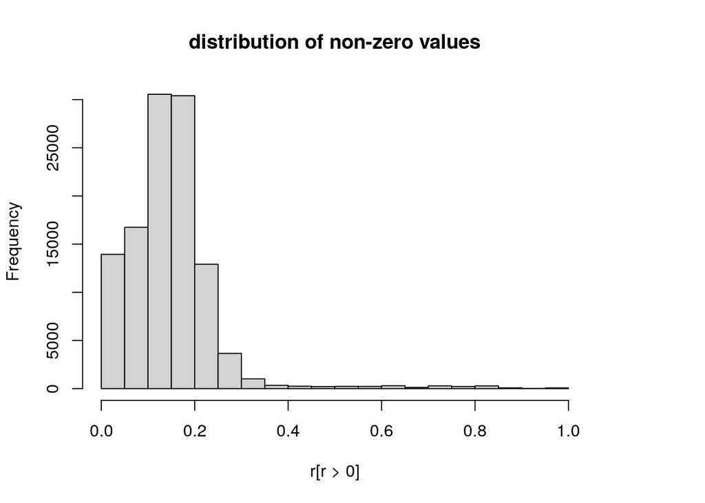

```r
hist(r[r > 0], main = 'distribution of non-zero values')
```

### 3.3.2 Ocean acidification from CHI Pace of Change (2017 data year)

- dir: `git-annex/impact_acceleration/stressors/oa/final`
  - file: `oa_2017_rescaled_mol.tif`
- These are in Mollweide but at 934 meter resolution… reproject to 10 km
- Or, use OHI or CHI processing script to process from raw data?

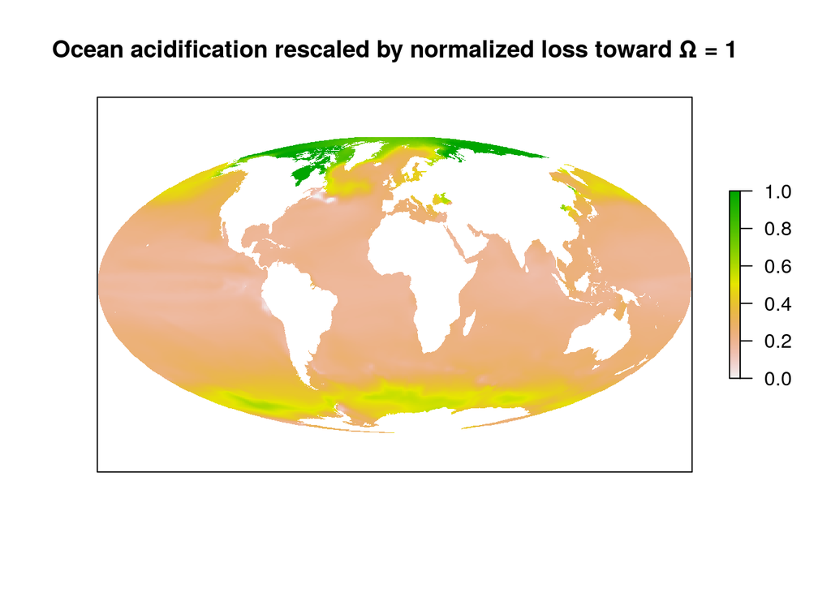

```r
oa_f <- here('_data/stressors_mol/oa_2017.tif')
### unlink(oa_f)

if(!file.exists(oa_f)) {
  orig_f <- here_ohi(paste('git-annex/impact_acceleration/stressors/oa/final',
                           'oa_2017_rescaled_mol.tif', sep = '/'))
  orig_r <- raster(orig_f)
  # class      : RasterLayer
  # dimensions : 19305, 38610, 745366050  (nrow, ncol, ncell)
  # resolution : 934.4789, 934.4789  (x, y)
  # extent     : -18040095, 18040134, -9020047, 9020067  (xmin, xmax, ymin, ymax)
  # crs        : +proj=moll +lon_0=0 +x_0=0 +y_0=0 +ellps=WGS84 +units=m +no_defs
  # source     : oa_2017_rescaled_mol.tif
  # names      : oa_2017_rescaled_mol
  # values     : 0, 1  (min, max)

  ### Aggregate from 934 m to ~ 10 km
  agg_r <- aggregate(orig_r, fact = 10, fun = 'mean', progress = 'text')
  oa_r <- projectRaster(agg_r, ocean_rast, progress = 'text')

  ### round to drop ludicrous precision then save out
  values(oa_r) <- round(values(oa_r), 5)
  writeRaster(oa_r, oa_f)

}

r <- raster(oa_f)

plot(r, axes = FALSE,
     main = 'Ocean acidification rescaled by normalized loss toward Ω = 1')
```

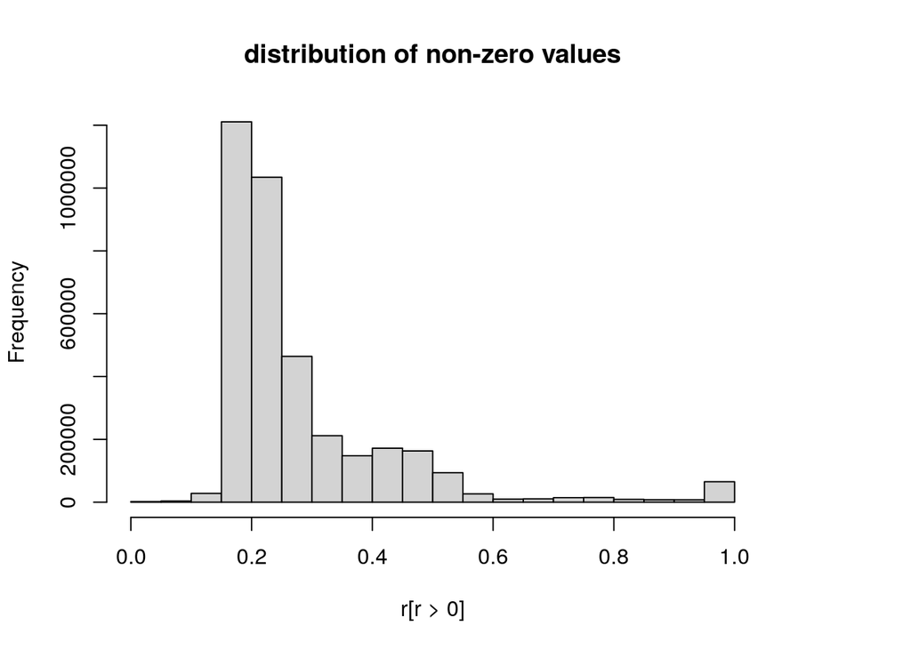

```r
hist(r[r > 0], main = 'distribution of non-zero values')
```

### 3.3.3 Ultraviolet radiation from OHI 2021

- dir: `git-annex/globalprep/prs_uv/v2021/int/rescaled/`
  - file: `annual_diff_2016_2020_rescaled.tif`

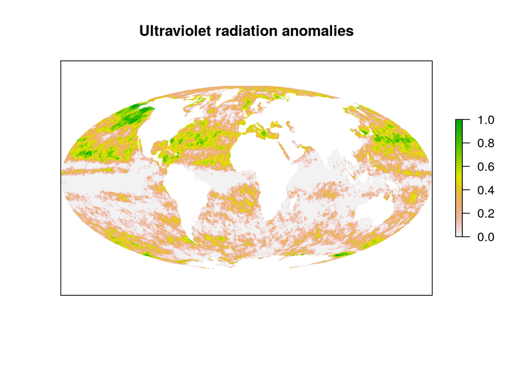

```r
uv_f <- here('_data/stressors_mol/uv_2020.tif')
### unlink(uv_f)

if(!file.exists(uv_f)) {
  orig_f <- here_ohi(paste('git-annex/globalprep/prs_uv/v2021/int/rescaled',
                           'annual_diff_2016_2020_rescaled.tif', sep = '/'))
  orig_r <- raster(orig_f)
  # class      : RasterLayer
  # dimensions : 180, 360, 64800  (nrow, ncol, ncell)
  # resolution : 1, 1  (x, y)
  # extent     : -180, 180, -90, 90  (xmin, xmax, ymin, ymax)
  # crs        : +proj=longlat +datum=WGS84 +no_defs
  # source     : annual_diff_2016_2020_rescaled.tif
  # names      : annual_diff_2016_2020_rescaled
  # values     : 0, 1  (min, max)

  ### No need to aggregate - native res much greater than analysis res
  uv_r <- projectRaster(orig_r, ocean_rast, progress = 'text')
  uv_r <- mask(uv_r, ocean_rast)

  ### round to drop ludicrous precision then save out
  values(uv_r) <- round(values(uv_r), 5)
  writeRaster(uv_r, uv_f, overwrite = TRUE)
}

r <- raster(uv_f)

plot(r, axes = FALSE,
     main = 'Ultraviolet radiation anomalies')
```

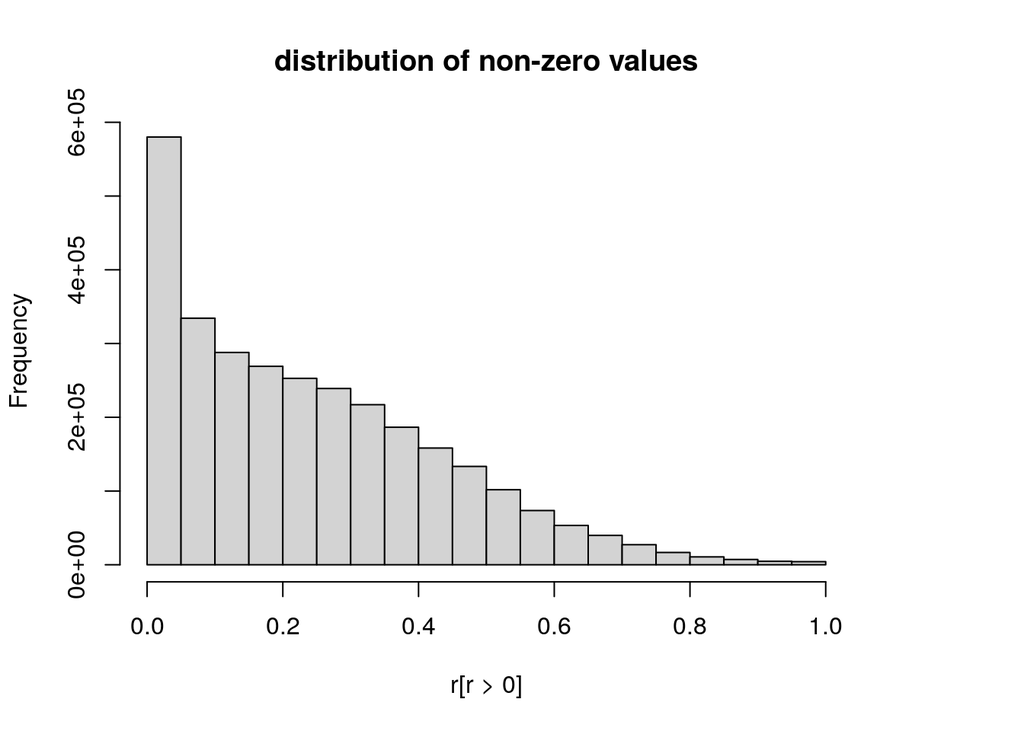

```r
hist(r[r > 0], main = 'distribution of non-zero values')
```